# Assignment2Notebook

Fengfan

07/10/2021

## Packages

**Install *Tidyverse*** `install.packages("tidyverse")`  
Tidyverse library is a superset of `ggplot2` library

**Load library**

```r
library(tidyverse)
```

**Load Data from packages** `Stat2Data` package contains information about 908 Hawks `install.packages("Stat2Data")`

```r
library(Stat2Data)
data("Hawks")

# Load data from the packages
hawksSmall<-drop_na(select(Hawks,Age,Day,Month,Year,CaptureTime,Species,Wing,Weight,Tail))

head(hawksSmall)
```

```
##   Age Day Month Year CaptureTime Species Wing Weight Tail
## 1   I  19     9 1992       13:30      RT  385    920  219
## 2   I  22     9 1992       10:30      RT  376    930  221
## 3   I  23     9 1992       12:45      RT  381    990  235
## 4   I  23     9 1992       10:50      CH  265    470  220
## 5   I  27     9 1992       11:15      SS  205    170  157
## 6   I  28     9 1992       11:25      RT  412   1090  230
```

### 1.1 Type of Variables

```r
dim(hawksSmall)
```

```
## [1] 897   9
```

It shows that the data have 897 rows and 9 columns.

```r
mode(hawksSmall)
```

```
## [1] "list"
```

For each of the following variables say whether they continuous, discrete or categorical. Discuss this with your colleagues.

1. Month -> Categorical [x] Numerical, Discrete
2. Species -> Categorical
3. Age -> Discrete [x] Ordinal
4. Wing -> Discrete [x] Numerical, Continuous
5. Weight -> Continous (Numerical)

### 1.2 What’s wrong with this plot?

Write down some problems with the plot displayed below.

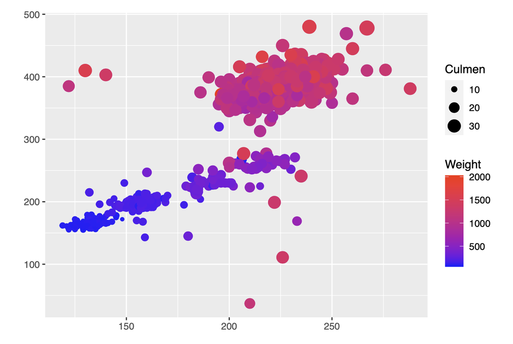

### 1.3 Generate a histogram

Next use a combination of the functions `ggplot()` and geom_histogram to create a histogram plot of the weights of the Hawks within the hawksSmall data frame with bin widths of 100 grams. Your result should look something like this:

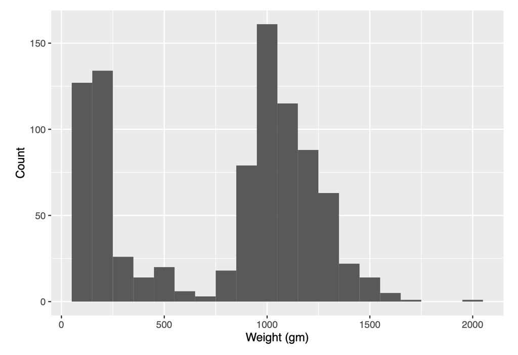

Codes here:

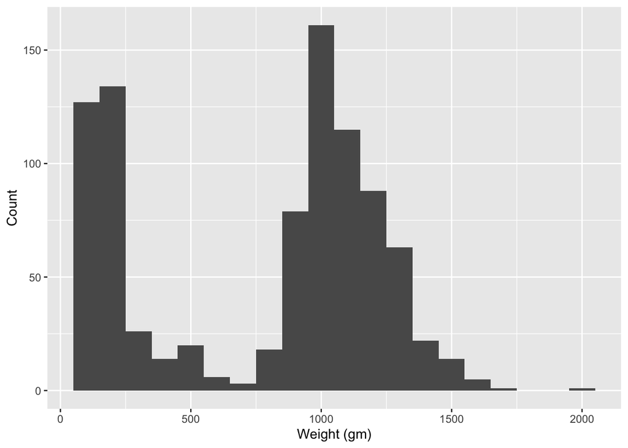

```r
# aes() are used to draw selected features of the data.
# Assign the binwidth argument to specify the binwidth of the histogram.
hawks_histogram <- ggplot(hawksSmall, aes(Weight)) + geom_histogram(binwidth = 100)
# Here we use labs() to rename the label.
hawks_histogram + labs(x="Weight (gm)", y="Count")
```

**Describe the aesthetic used within this plot**.

Weight are used in this plot.

**Which term best describes the shape of the data distribution of Hawk weights: “Unimodal”, “Bimodal” or “Trimodal”?**

Answer: **Bimodal**

### 1.4 Generate a density plot

Use a combination of the functions ggplot() and geom_density() to create a density plot of the tail lengths of the Hawks within the hawksSmall data frame.

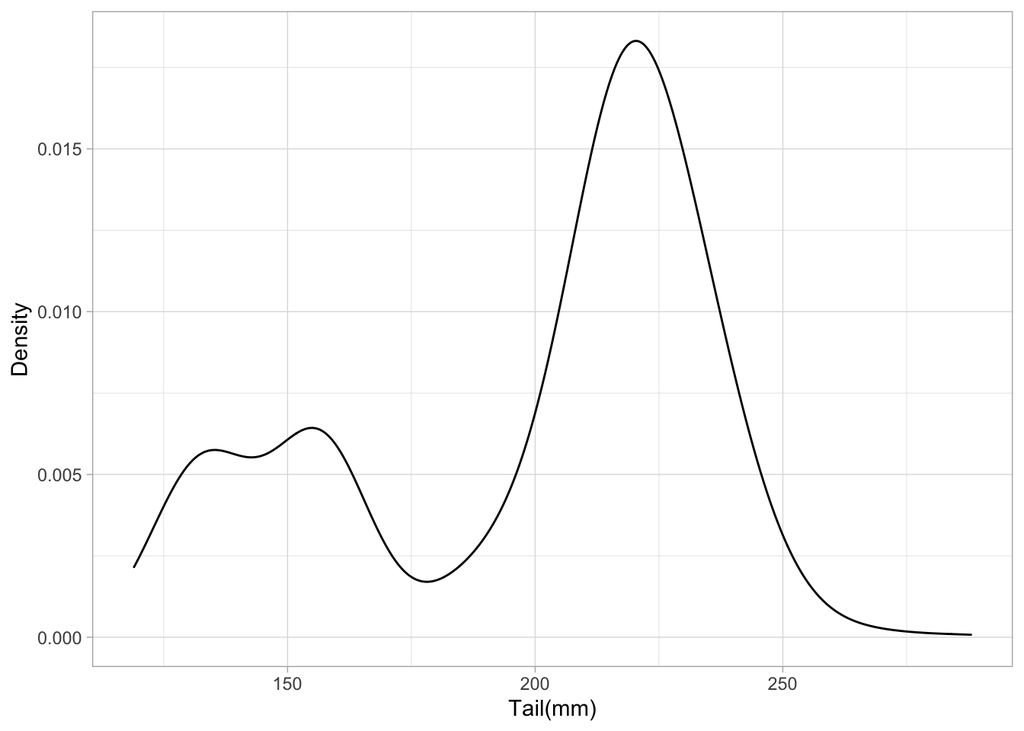

```r
hawks_density <- ggplot(hawksSmall, aes(Tail)) + geom_density()
hawks_density + labs(x="Tail(mm)", y="Density")
```

Recreate your plot with the argument adjust = 0.5 and adjust = 1. Describe the role played by the adjust argument within the geom_density() function. How many modes does the data distribution of Hawk tail lengths have?

Answer: **3 modes**

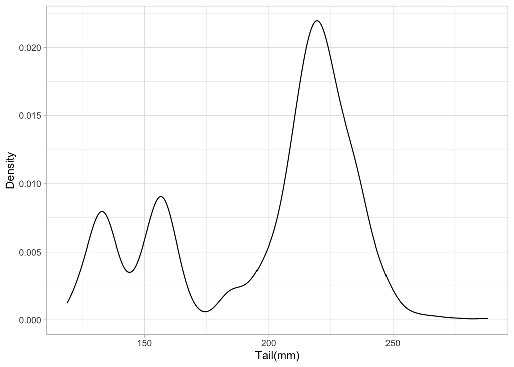

```r
# The default value of adjust is 1, change it to 0.5
hawks_density <- ggplot(hawksSmall, aes(Tail)) + geom_density(adjust=0.5)
hawks_density + labs(x="Tail(mm)", y="Density")
```

Create the following plots for yourself:

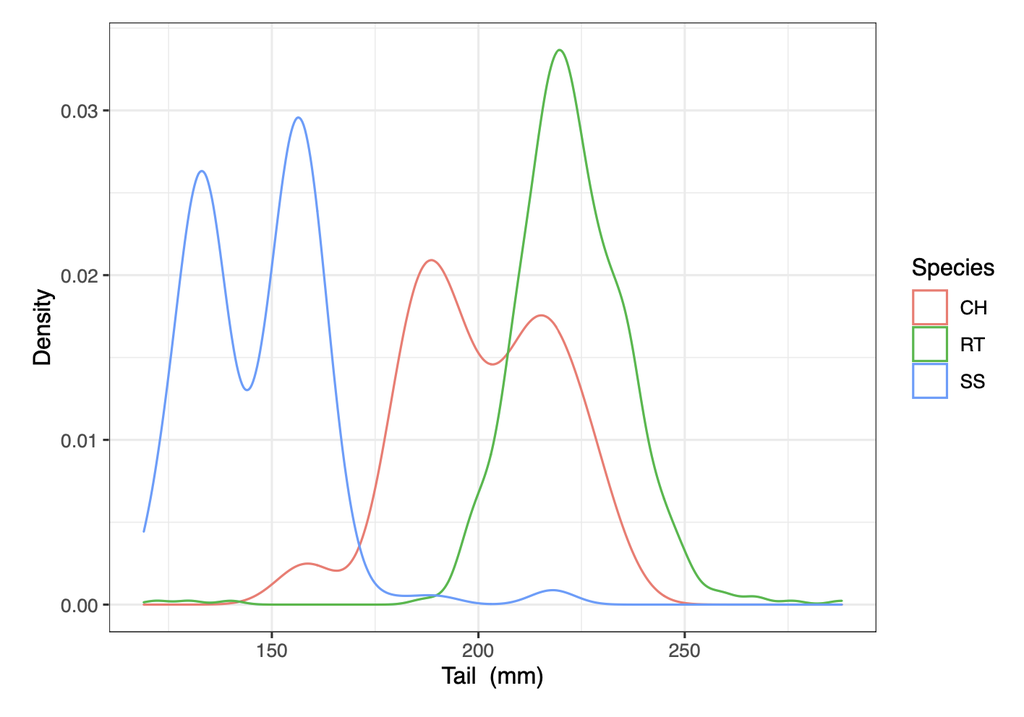

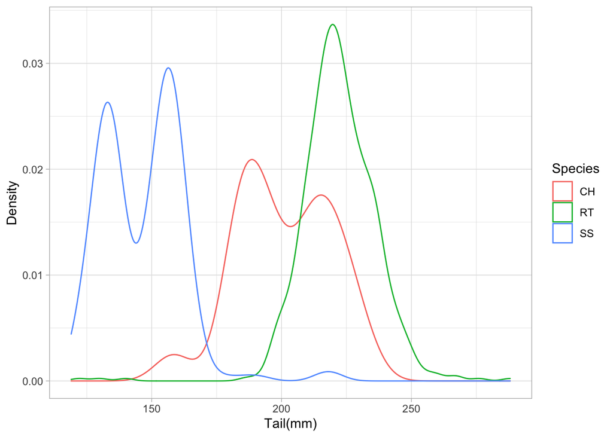

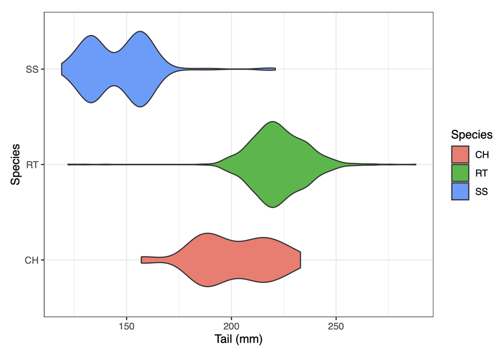

```r
ggplot(hawksSmall, aes(Tail, colour=Species)) + geom_density() + labs(x="Tail(mm)", y="Density")
```

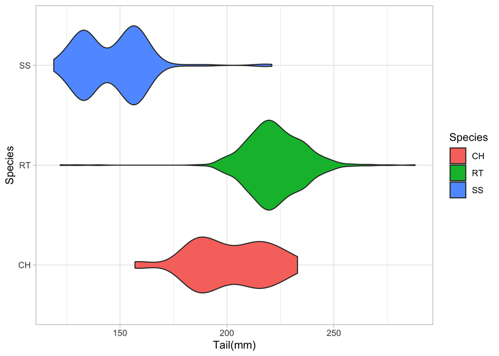

```r
ggplot(hawksSmall, aes(Tail, Species, fill=Species)) + geom_violin() + labs(x="Tail(mm)", y="Species")
```

### 1.5 Scatter plots

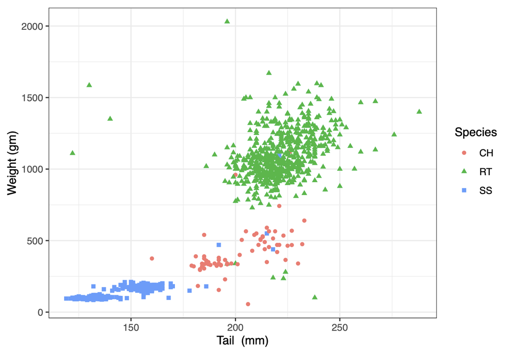

How many aesthetics are present within the following plot? -> **X, Y, color, glyphs** [Answer: 1. The tail length is mapped to the horizontal position. 2. The weight is mapped to the vertical positions. 3. The species is mapped to the colour. 4. The species is mapped to shape.]

What are the glyphs within this plot? -> **Square, Circle, Triangle**

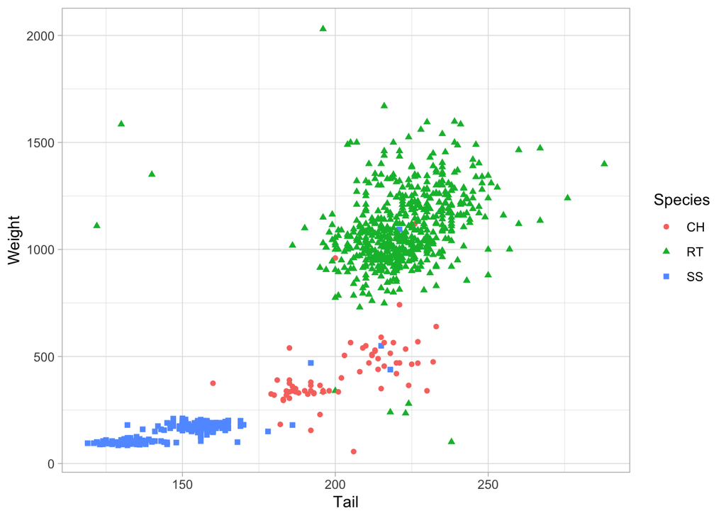

```r
ggplot(hawksSmall, aes(Tail, Weight, color=Species, shape=Species)) + geom_point()
```

### 1.6 Trend lines and facet wraps

Generate the following plot using the ggplot(), geom_point(), geom_smooth() and facet_wrap() functions.

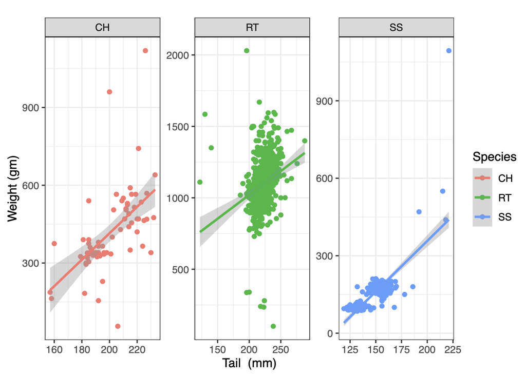

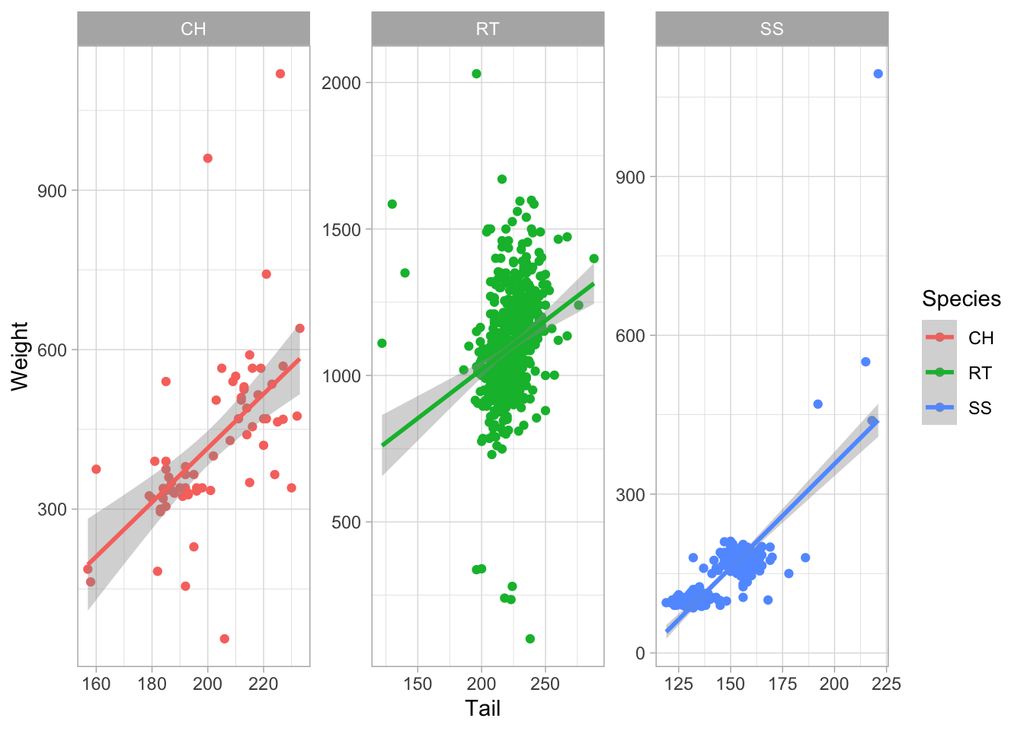

```r
ggplot(hawksSmall, aes(Tail, Weight, color=Species)) + geom_point() + geom_smooth(method=lm) + facet_wrap(vars(Species), scales="free")
```

What are the visual cues being used within this plot? Based on the above plot, what can we say about the relationship between the weight of the hawks and their tail lengths?

As an additional challenge, if you have time, you could try adding an annotation to your plot which highlights the weight of the heaviest hawk in the data set.

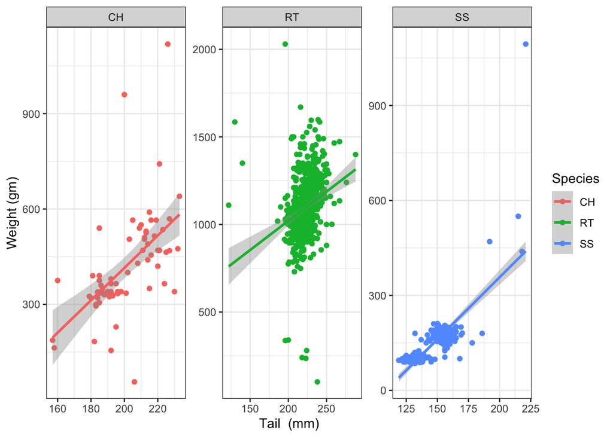

```r
tail_weight_plt<-ggplot(data=hawksSmall,aes(x=Tail,
                                            y=Weight,color=Species))+
  geom_point()+xlab("Tail  (mm)")+ylab("Weight (gm)")+
  geom_smooth(method="lm")+theme_bw()+facet_wrap(~Species,scales = "free")
tail_weight_plt
```

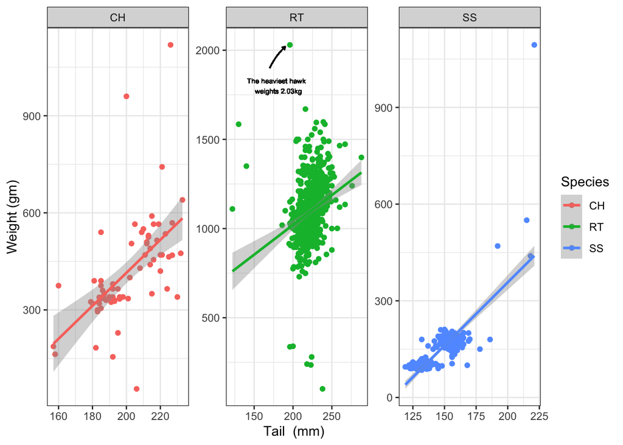

```r
max_weight<-max(hawksSmall$Weight)
label=paste("The heaviest hawk \n weights ", as.character(max_weight/1000),"kg",sep="")

tail_weight_plt+geom_curve(x=170,xend=190,y=1900,yend=2020,
                           arrow=arrow(length=unit(0.1,"cm")),
             curvature = -0.1,color="black")+
  geom_text(x=180,y=1800,label=label,size=2,color="black")
```

**References**

[`vars()`](https://ggplot2.tidyverse.org/reference/vars.html)  
It’s to takes inputs to be evaluated in the context of a dataset. The results (the vectors that the variable represents or the results of the expressions) are used to form faceting groups.

[`geom_smooth()`](https://ggplot2.tidyverse.org/reference/geom_smooth.html?q=geom%20_%20smooth#arguments)  
Aids the eye in seeing patterns in the presence of overplotting. `method` arguments are used to select the smoothing function.

## 2.Data wrangling

### 2.1 Select and filter functions

Use a combination of the select() and filter() functions to generate a data frame called “hSF” which is a sub-table of the original Hawks data frame with the following characteristics:

1. Your data frame should include the columns:
1. “Wing”
2. “Weight”
3. “Tail”
2. Your data frame should contain a row for every hawk such that:
1. They belong to the species of Red-Tailed hawks
2. They have weight at least 1kg

```r
hSF <- Hawks %>% filter(Species=="RT" & Weight >= 1000) %>% select(Wing, Weight, Tail)
dim(hSF)
```

```
## [1] 398   3
```

How many variables does the dataframe hSF have? What would you say to communicate this information to a Machine Learning practitioner?

Answer: **Three. Features.**

How many examples does the dataframe hSF have? How many observations? How many cases?

Answer: **398 records.**

```r
hSF %>% nrow()
```

```
## [1] 398
```

### 2.2 The arrange function

Use the arrange() function to sort the hSF data frame created in the previous section so that the rows appear in order of increasing wing span.

```r
hSF <- hSF %>% arrange(Wing)
head(hSF)
```

```
##    Wing Weight Tail
## 1  37.2   1180  210
## 2 111.0   1340  226
## 3 199.0   1290  222
## 4 241.0   1320  235
## 5 262.0   1020  200
## 6 277.0   1500  207
```

### 2.3 Join and rename functions

```r
name_map <- data.frame(species_code=c("CH", "RT", "SS"), species_name_full=c("Cooper's", "Red-tailed", "Sharp-shinned"))
name_map
```

```
##   species_code species_name_full
## 1           CH          Cooper's
## 2           RT        Red-tailed
## 3           SS     Sharp-shinned
```

Use a combination of the functions left_join(), the rename() and the `select()` functions to create a new data frame called “hawksFullName” which is the same as the “Hawks” data frame except that the Species column contains the full names rather than the two letter codes.

```r
hawksFullName <- Hawks %>% left_join(name_map, by=c("Species"="species_code")) %>% select(!Species) %>% rename(Species=species_name_full)
```

Use a combination of the head() and select() functions to print out the top seven rows of the columns “Species”, “Wing” and “Weight” of the data frame called “hawksFullName”. Do this without modifying the data frame you just created.

```r
hawksFullName %>% select("Species", "Wing", "Weight") %>% head(7)
```

```
##         Species Wing Weight
## 1    Red-tailed  385    920
## 2    Red-tailed  376    930
## 3    Red-tailed  381    990
## 4      Cooper's  265    470
## 5 Sharp-shinned  205    170
## 6    Red-tailed  412   1090
## 7    Red-tailed  370    960
```

Does it matter what type of join function you use here?  
In what situations would it make a difference?

Answer: **Absolutely not, if there are na values in both data frame, the result will be different.**

### 2.4 The mutate function

Suppose that the fictitious “Healthy Hawks Society” has proposed a new measure called the “bird BMI” which attempts to measure mass of a hawk standardized by their wing span. The bird BMI is equal to the weight of the hawk (in grams) divided by their wing span (in millimeters) squared. That is,

$$Bird-BMI := 1000 × Weight/Wing-span^2.$$

```r
hawksWithBMI <- Hawks %>% mutate(bird_BMI=1000*Weight/(Wing)**2) %>% select(Species, bird_BMI) %>% arrange(desc(bird_BMI))
```

Use the filter() function to remove those cases where the bird BMI exceeds 100 from your data frame. Then generate a violin plot of your data which shows the distribution of “bird BMIs” broken down by species.

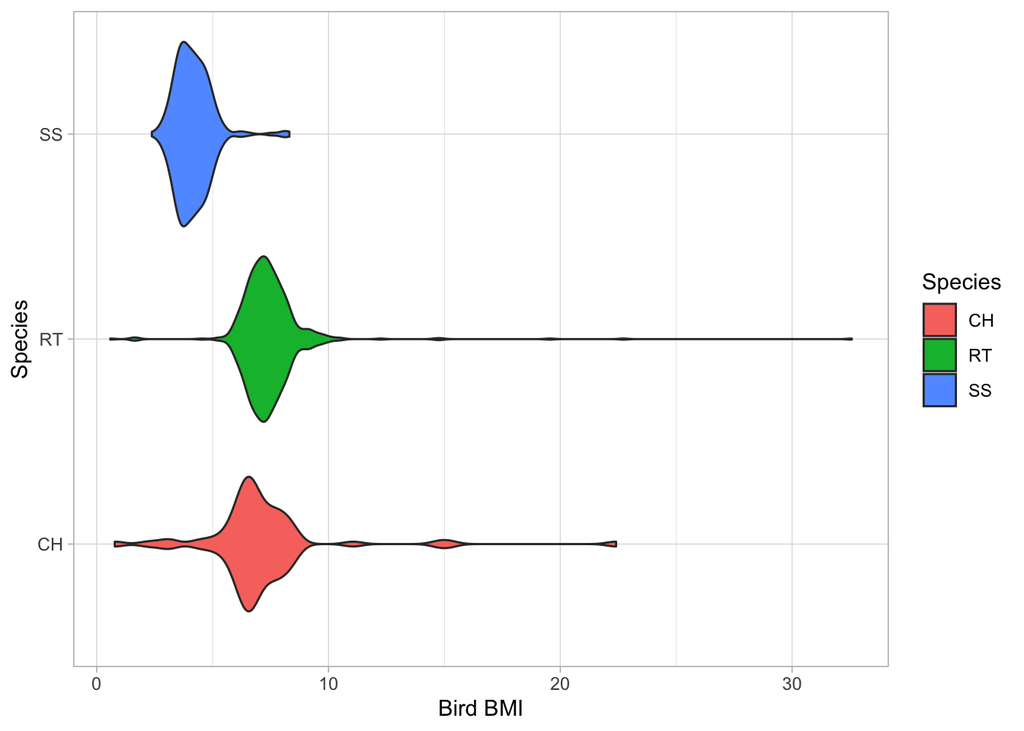

```r
ggplot(hawksWithBMI %>% filter(bird_BMI<=100), aes(bird_BMI, Species, fill=Species)) + geom_violin() + labs(x="Bird BMI")
```

**IDK**: What’s point to scale the x axies by log2?

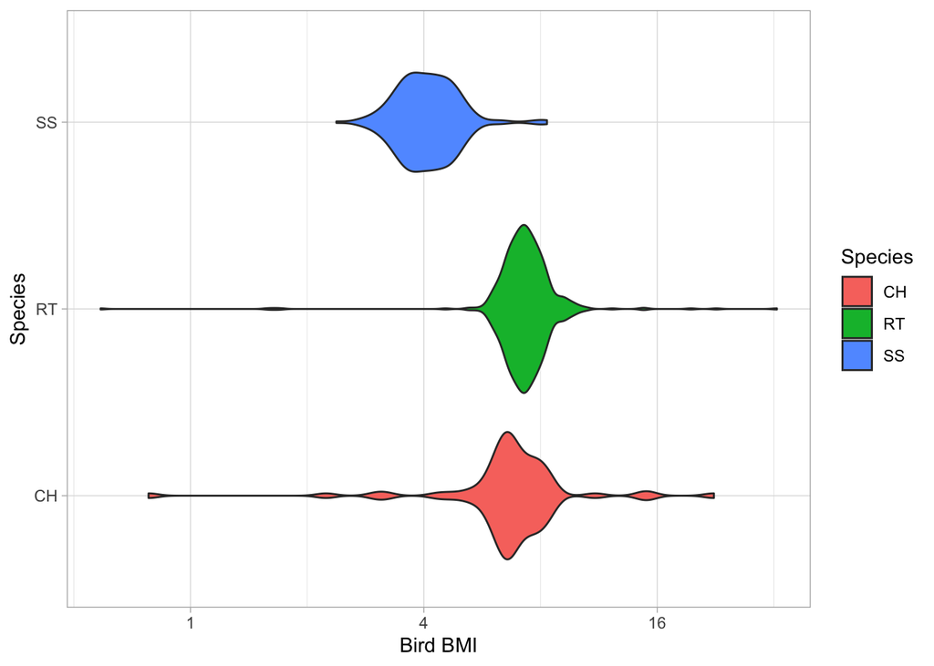

```r
ggplot(hawksWithBMI %>% filter(bird_BMI<=100), aes(bird_BMI, Species, fill=Species)) + geom_violin() + labs(x="Bird BMI") + scale_x_continuous(trans='log2')
```

### 2.5 Summarize and group-by functions

Using the dataframe “hawksFullName”, from problem 3 above, in combination with the summarize() and the groupby functions, create a summary table, broken down by Hawk species, which contains the following summary quantities:

1. The number of rows;
2. The mean average wing span in centimeters;
3. The median wing span in centimeters;
4. The trimmed mean average wing span in centimeters (trim=0.1);
5. The mean average of the ratio between wing span and tail length.

```r
hawksFullName %>% group_by(Species) %>% summarise(num_rows=n(), mn_wing=mean(Wing, na.rm=TRUE), md_wing=median(Wing, na.rm=TRUE), mean(Wing, trim=0.1, na.rm=TRUE), mean(Wing/Tail, na.rm=TRUE))
```

```
## # A tibble: 3 × 6
##   Species       num_rows mn_wing md_wing `mean(Wing, trim = … `mean(Wing/Tail, …
##   <chr>            <int>   <dbl>   <dbl>                <dbl>              <dbl>
## 1 Cooper's            70    244.     240                 243.               1.22
## 2 Red-tailed         577    383.     384                 385.               1.73
## 3 Sharp-shinned      261    185.     191                 184.               1.26
```

Next create a summary table of the following form: Your summary table will show the number of missing values, broken down by species, for the columns Wing, Weight, Culmen, Hallux, Tail, StandardTail, Tarsus and Crop. You can complete this task by combining the select(), group_by(), summarize(), across(), everything(), sum() and is.na() functions.

```r
hawksFullName %>% group_by(Species) %>% summarise(across(c(Wing, Weight, Culmen, Hallux, Tail, StandardTail, Tarsus, Crop), ~sum(is.na(.x))))
```

```
## # A tibble: 3 × 9
##   Species        Wing Weight Culmen Hallux  Tail StandardTail Tarsus  Crop
##   <chr>         <int>  <int>  <int>  <int> <int>        <int>  <int> <int>
## 1 Cooper's          1      0      0      0     0           19     62    21
## 2 Red-tailed        0      5      4      3     0          250    538   254
## 3 Sharp-shinned     0      5      3      3     0           68    233    68
```

```r
hawksFullName %>% group_by(Species) %>% summarise(across(c(Wing, Weight, Culmen, Hallux, Tail, StandardTail, Tarsus, Crop), ~sum(is.na(.x))))
```

```
## # A tibble: 3 × 9
##   Species        Wing Weight Culmen Hallux  Tail StandardTail Tarsus  Crop
##   <chr>         <int>  <int>  <int>  <int> <int>        <int>  <int> <int>
## 1 Cooper's          1      0      0      0     0           19     62    21
## 2 Red-tailed        0      5      4      3     0          250    538   254
## 3 Sharp-shinned     0      5      3      3     0           68    233    68
```

Question:  
[What is ‘~’ used for?](https://purrr.tidyverse.org/articles/other-langs.html)  
[What does ‘.x’ mean?](https://www.reddit.com/r/Rlanguage/comments/hcp4j7/what_does_x_and_p_mean_when_writing_functions/)

For the every() function .x just stands for the vector you’re inputting, and .p stands for the predicate function you want to test for. They could just as well be called .stuff and .things.

Now onto the tilde ~. When using purrr it’s used to make anonymous functions easier to write. Using your example these three pieces of code do the exact same thing, but one is less typing:

```r
every(1:3, function(x) x > 1)
every(1:3, function(.x) .x > 1)
every(1:3, ~ .x > 1)
```

> Now onto the tilde ~. When using purrr it’s used to make anonymous functions easier to write. Using your example these three pieces of code do the exact same thing, but one is less typing:  
> every(1:3, function(x) x > 1)  
> every(1:3, function(.x) .x > 1)  
> every(1:3, ~ .x > 1)  
> .x just stands for the vector you’re inputting

## 3. Exploratory data analysis

### 3.1 Combining location estimators with the summarise function

Use a combination of the summarise(), mean() and median() to compute the sample mean, sample median and trimmed sample mean (with q = 0.1) of the Hawk’s wing length and Hawk’s weight.

```r
Hawks %>% summarize(Wing_mean=mean(Wing, na.rm=TRUE), Wing_t_mean=mean(Wing, trim=0.1, na.rm=TRUE), Wing_med=median(Wing, na.rm=TRUE), Weight_mean=mean(Weight, na.rm=TRUE), Weight_t_mean=mean(Weight, trim=0.1, na.rm=TRUE), Weight_med=median(Weight, na.rm=TRUE))
```

```
##   Wing_mean Wing_t_mean Wing_med Weight_mean Weight_t_mean Weight_med
## 1  315.6375    322.2297      370    772.0802      779.3681        970
```

Combine with the group_by() function to obtain a break down by species.

```r
Hawks %>% group_by(Species) %>% summarize(Wing_mean=mean(Wing, na.rm=TRUE), Wing_t_mean=mean(Wing, trim=0.1, na.rm=TRUE), Wing_med=median(Wing, na.rm=TRUE), Weight_mean=mean(Weight, na.rm=TRUE), Weight_t_mean=mean(Weight, trim=0.1, na.rm=TRUE), Weight_med=median(Weight, na.rm=TRUE))
```

```
## # A tibble: 3 × 7
##   Species Wing_mean Wing_t_mean Wing_med Weight_mean Weight_t_mean Weight_med
##   <fct>       <dbl>       <dbl>    <dbl>       <dbl>         <dbl>      <dbl>
## 1 CH           244.        243.      240        420.          410.       378.
## 2 RT           383.        385.      384       1094.         1089.      1070
## 3 SS           185.        184.      191        148.          140.       155
```

### 3.2 Location and dispersion estimatiors under linear transformations

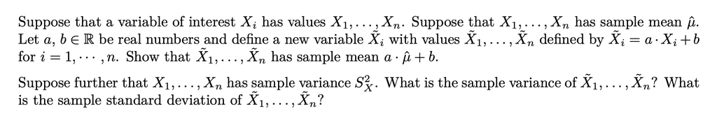

### 3.3 Robustness of location estimators

In this exercise we shall investigate the robustness of several location estimators: The sample mean, sample median and trimmed mean.

We begin by extracting a vector called “hal” consisting of the talon lengths of all the hawks with any missing values removed.

```r
hal<-Hawks$Hallux # Extract the vector of hallux lengths
hal<-hal[!is.na(hal)] # Remove any nans
```

To investigate the effect of outliers on estimates of location we generate a new vector called “corrupted_hall” with 10 outliers each of value 100 created as follows:

```r
outlier_val<-100
num_outliers<-10
corrupted_hal<-c(hal,rep(outlier_val,times=num_outliers))
```

We can then compute the mean of the original sample and the corrupted sample as follows.

```r
mean(hal)
```

```
## [1] 26.41086
```

```r
mean(corrupted_hal)
```

```
## [1] 27.21776
```

Now let’s investigate what happens as the number of outliers changes from 0 to 1000. The code below generates a vector called “means_vect” which gives the sample means of corrupted samples with different numbers of outliers. More precisely, means_vect is a vector of length 1001 with the i-th entry equal to the mean of a sample with i − 1 outliers.

```r
num_outliers_vect<-seq(0,1000)
means_vect<-c()

for(num_outliers in num_outliers_vect){
  corrupted_hal<-c(hal,rep(outlier_val,times=num_outliers))
  means_vect<-c(means_vect,mean(corrupted_hal))
}

length(means_vect)
```

```
## [1] 1001
```

Copy and modify the above code to create an additional vector called “medians_vect” of length 1001 with the i-th entry equal to the median of a sample “corrupted_hal” with i − 1 outliers.

```r
medians_vect <- c()

for(num_outliers in num_outliers_vect) {
  corrupted_hal <- c(hal, rep(outlier_val, times=num_outliers))
  medians_vect <- c(medians_vect, median(corrupted_hal))
}

length(medians_vect)
```

```
## [1] 1001
```

Amend the code further to add an additional vector called “t_means_vect” of length 1001 with the i-th entry equal to the trimmed mean of a sample with i−1 outliers, where the trimmed mean has a trim fraction q = 0.1.

```r
t_means_vect <- c()

for(num_outliers in num_outliers_vect) {
  corrupted_hal <- c(hal, rep(outlier_val, times=num_outliers))
  t_means_vect <- c(t_means_vect, mean(corrupted_hal, trim = 0.1))
}

length(t_means_vect)
```

```
## [1] 1001
```

You should now have four vectors: “num_outliers_vect”, “means_vect”, “medians_vect” and “t_means_vect”. Combine these vectors into a data frame with the following code.

```r
df_means_medians <- data.frame(num_outliers=num_outliers_vect,mean=means_vect,t_mean=t_means_vect,median=medians_vect)
```

Now use the code below to reshape and plot the data. The function pivot_longer() below is used to reshape the data. Don’t worry if this operation is unclear at this stage. Its use will be explained soon.

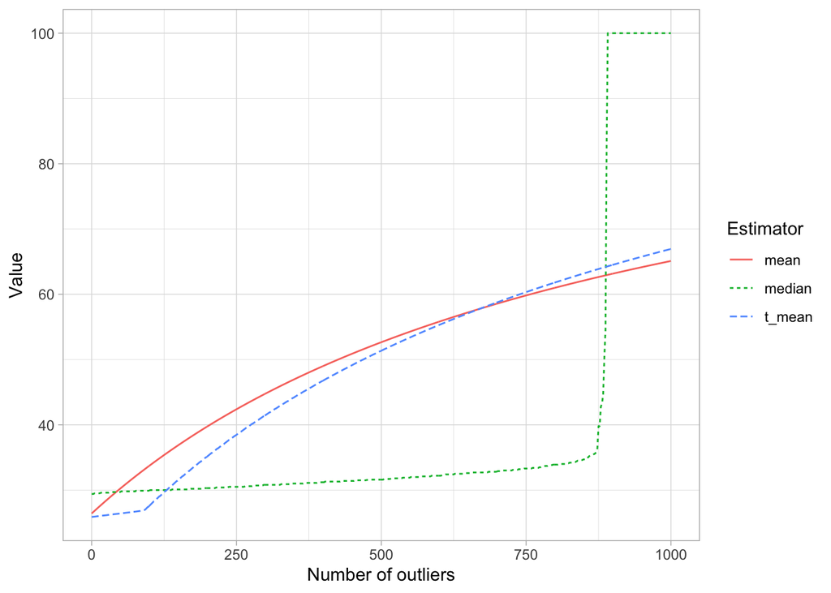

```r
df_means_medians%>%
  pivot_longer(!num_outliers, names_to = "Estimator", values_to = "Value")%>%
  ggplot(aes(x=num_outliers,color=Estimator,linetype=Estimator,y=Value))+
  geom_line()+xlab("Number of outliers")
```

### 3.4 Box plots and outliers

Use the functions ggplot() and geom_boxplot() to create a box plot which summarises the distribution of hawk weights broken down by species.

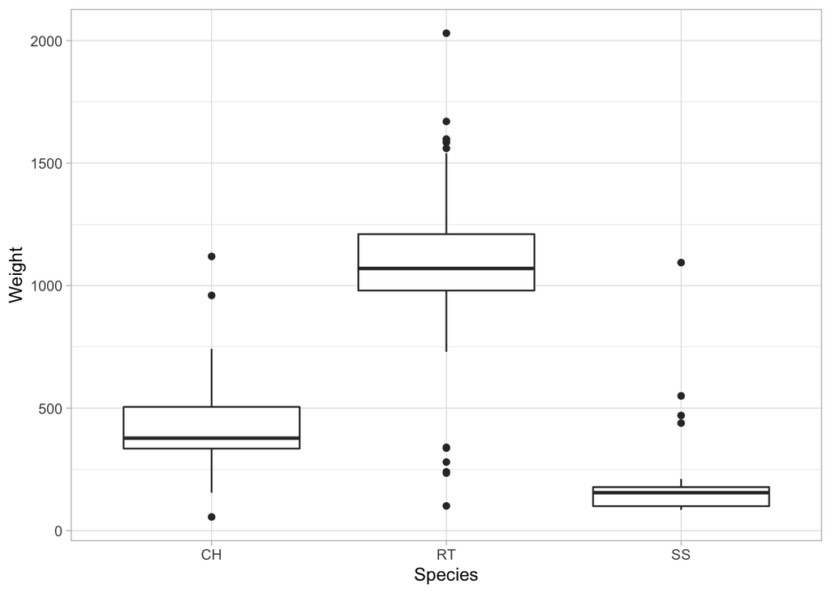

```r
ggplot(Hawks, aes(Species, Weight)) + geom_boxplot()
```

Suppose we have a sample X1, · · · , Xn. Let q25 denote the 0.25-quantile of the sample and let q75 denote the 0.75-quantile of the sample. We can then define the interquartile range, denoted IQR by `IQR := q75 − q25`. In the context of boxplots and outlier Xi is any numerical value such that the following holds if either of the following holds:
$$X_i < q25 - 1.5 \times IQR$$
$$X_i > q75 + 1.5 \times IQR$$

Create a function called “num_outliers” which computes the number of outliers within a sample (with missing values excluded).

Now combine your function num_outliers() with the functions `group_by()` and `summarise()` to com- pute the number of outlier for the three samples of hawk weights broken down by specied.

```r
# num_outliers <- function(.data, feature) {
#   q25 <-quantile(.data[feature], 0.25, na.rm=TRUE)
#   q75 <-quantile(.data[feature], 0.75, na.rm=TRUE)
#   iq_range <- q75 - q25
#   outliers <- .data[feature][feature > q75+1.5*iq_range | feature < q25-1.5*iq_range | is.na(feature)]
#   return (sum(is.na(.data[feature]))+nrow(outliers))
# }


num_outliers <- function(feature) {
  q25 <-quantile(feature, 0.25, na.rm=TRUE)
  q75 <-quantile(feature, 0.75, na.rm=TRUE)
  iq_range <- q75 - q25
  outliers <- feature[feature > q75+1.5*iq_range | feature < q25-1.5*iq_range ]
  return (sum(is.na(feature))+length(outliers))
}
```

```r
ch_hawks <- Hawks %>% filter(Species=="CH")
ch_weight <- ch_hawks["Weight"]

q25 <- quantile(ch_weight, 0.25, na.rm=TRUE)
q75 <- quantile(ch_weight, 0.75, na.rm=TRUE)
iq_range <- q75 - q25
outliers <- ch_weight[ch_weight < q25-1.5*iq_range | ch_weight > q75+1.5*iq_range]
```

```r
Hawks %>% group_by(Species) %>% summarise(num_outliers_weight=num_outliers(Weight))
```

```
## # A tibble: 3 × 2
##   Species num_outliers_weight
##   <fct>                 <int>
## 1 CH                        3
## 2 RT                       23
## 3 SS                       14
```

### 3.5 Covariance and correlation under linear transformations

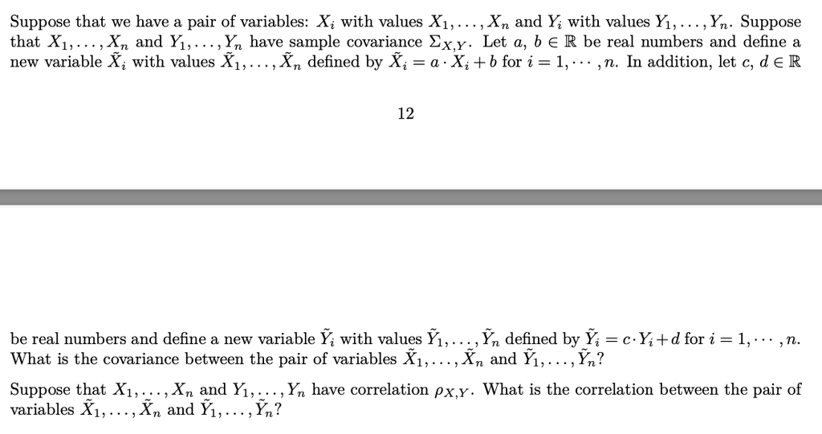

**Answer:** $\hat\rho_{X, Y}=a^2\rho_{X,Y}$